# Employment Prediction 2022 in Berlin

### Paula Moyano Sánchez

**Data**: the data for this project comes from the open data source of Berlin Brandenburg [here](https://www.statistik-berlin-brandenburg.de/). Currently the spreadsheet is not available on the website.

**Motivation**: the estimation can be especially interesting regarding the influence of COVID-19 pandemic in the last few years.

#### Import packages

First we import the key data analysis modules

```python
import pandas as pd # primary data structure library
import numpy as np # useful for many scientific computing in Python
print("Packages successfully imported")
```

```
Packages successfully imported
```

## Loading data

The data was downloaded from the website of the board of statistics for Berlin and Brandenburg. This data is under MIT licence publically available.

```python
# read_excel() method:
# to download (and import) the datasest
# and read it into a pandas dataframe

df_original_de = pd.read_excel('Erwerbstaetige.xlsx',
                             # https://www.statistik-berlin-brandenburg.de/statistiken/langereihen/dateien/Erwerbstaetige.xlsx',
                             sheet_name='1',
                             # delimiter=', ',
                             skiprows=range(2),
                             nrows=12,
                             names=['Unnamed: 0', 'Wirtschaftsbereich (WZ 2008)','1991','1992','1993','1994','1995','1996','1997','1998','1999','2000','2001','2002','2003','2004','2005','2006','2007','2008','2009','2010','2011','2012','2013','2014','2015','2016','2017','2018','2019','2020'], # To clean the names
                           )
print('Dataset downloaded and read into a pandas dataframe')
df_original_de.head() # head () function to read the top rows/items of our dataset
```

```
Dataset downloaded and read into a pandas dataframe
```

|  | Unnamed: 0 | Wirtschaftsbereich (WZ 2008) | 1991 | 1992 | 1993 | 1994 | 1995 | 1996 | 1997 | 1998 | ... | 2011 | 2012 | 2013 | 2014 | 2015 | 2016 | 2017 | 2018 | 2019 | 2020 |
| --- | --- | --- | --- | --- | --- | --- | --- | --- | --- | --- | --- | --- | --- | --- | --- | --- | --- | --- | --- | --- | --- |
| 0 | NaN | NaN | NaN | NaN | NaN | NaN | NaN | NaN | NaN | NaN | ... | NaN | NaN | NaN | NaN | NaN | NaN | NaN | NaN | NaN | NaN |
| 1 | NaN | NaN | 1 000 Personen | NaN | NaN | NaN | NaN | NaN | NaN | NaN | ... | NaN | NaN | NaN | NaN | NaN | NaN | NaN | NaN | NaN | NaN |
| 2 | NaN | Erwerbstätige insgesamt | 1705.996 | 1678.583 | 1670.743 | 1659.852 | 1661.326 | 1635.439 | 1601.119 | 1588.911 | ... | 1707.110 | 1744.888 | 1778.720 | 1812.299 | 1851.120 | 1902.334 | 1961.127 | 2022.884 | 2066.667 | 2058.631 |
| 3 | NaN | Land- und Forstwirtschaft, Fischerei | 1.235 | 1.170 | 1.089 | 1.102 | 1.144 | 1.093 | 1.022 | 0.981 | ... | 0.576 | 0.519 | 0.468 | 0.453 | 0.461 | 0.483 | 0.535 | 0.672 | 0.694 | 0.881 |
| 4 | NaN | Produzierendes Gewerbe | 453.123 | 420.845 | 401.526 | 384.412 | 369.065 | 346.572 | 330.550 | 313.810 | ... | 216.698 | 221.126 | 220.536 | 220.826 | 221.085 | 218.730 | 221.288 | 226.548 | 227.326 | 223.320 |

5 rows × 32 columns

## Data preparation

We clean (wrang, mug) the original dataset to make it easier to create our visualizations

#### Remove rows not informative for visualization

```python
# drop() method to remove unnecessary rows

df_original_de.drop([0], axis=0, inplace=True)
df_original_de.head()
```

|  | Unnamed: 0 | Wirtschaftsbereich (WZ 2008) | 1991 | 1992 | 1993 | 1994 | 1995 | 1996 | 1997 | 1998 | ... | 2011 | 2012 | 2013 | 2014 | 2015 | 2016 | 2017 | 2018 | 2019 | 2020 |
| --- | --- | --- | --- | --- | --- | --- | --- | --- | --- | --- | --- | --- | --- | --- | --- | --- | --- | --- | --- | --- | --- |
| 1 | NaN | NaN | 1 000 Personen | NaN | NaN | NaN | NaN | NaN | NaN | NaN | ... | NaN | NaN | NaN | NaN | NaN | NaN | NaN | NaN | NaN | NaN |
| 2 | NaN | Erwerbstätige insgesamt | 1705.996 | 1678.583 | 1670.743 | 1659.852 | 1661.326 | 1635.439 | 1601.119 | 1588.911 | ... | 1707.110 | 1744.888 | 1778.720 | 1812.299 | 1851.120 | 1902.334 | 1961.127 | 2022.884 | 2066.667 | 2058.631 |
| 3 | NaN | Land- und Forstwirtschaft, Fischerei | 1.235 | 1.170 | 1.089 | 1.102 | 1.144 | 1.093 | 1.022 | 0.981 | ... | 0.576 | 0.519 | 0.468 | 0.453 | 0.461 | 0.483 | 0.535 | 0.672 | 0.694 | 0.881 |
| 4 | NaN | Produzierendes Gewerbe | 453.123 | 420.845 | 401.526 | 384.412 | 369.065 | 346.572 | 330.550 | 313.810 | ... | 216.698 | 221.126 | 220.536 | 220.826 | 221.085 | 218.730 | 221.288 | 226.548 | 227.326 | 223.320 |
| 5 | NaN | Produzierendes Gewerbe (ohne Baugewerbe) | 317.73 | 279.305 | 252.777 | 230.103 | 215.224 | 201.759 | 192.662 | 185.827 | ... | 137.763 | 139.433 | 137.967 | 138.539 | 138.641 | 135.864 | 136.330 | 138.598 | 136.878 | 132.730 |

5 rows × 32 columns

```python
# Drop row index [1]

df_original_de.drop([1], axis=0, inplace=True)
df_original_de.head()
```

|  | Unnamed: 0 | Wirtschaftsbereich (WZ 2008) | 1991 | 1992 | 1993 | 1994 | 1995 | 1996 | 1997 | 1998 | ... | 2011 | 2012 | 2013 | 2014 | 2015 | 2016 | 2017 | 2018 | 2019 | 2020 |
| --- | --- | --- | --- | --- | --- | --- | --- | --- | --- | --- | --- | --- | --- | --- | --- | --- | --- | --- | --- | --- | --- |
| 2 | NaN | Erwerbstätige insgesamt | 1705.996 | 1678.583 | 1670.743 | 1659.852 | 1661.326 | 1635.439 | 1601.119 | 1588.911 | ... | 1707.110 | 1744.888 | 1778.720 | 1812.299 | 1851.120 | 1902.334 | 1961.127 | 2022.884 | 2066.667 | 2058.631 |
| 3 | NaN | Land- und Forstwirtschaft, Fischerei | 1.235 | 1.170 | 1.089 | 1.102 | 1.144 | 1.093 | 1.022 | 0.981 | ... | 0.576 | 0.519 | 0.468 | 0.453 | 0.461 | 0.483 | 0.535 | 0.672 | 0.694 | 0.881 |
| 4 | NaN | Produzierendes Gewerbe | 453.123 | 420.845 | 401.526 | 384.412 | 369.065 | 346.572 | 330.550 | 313.810 | ... | 216.698 | 221.126 | 220.536 | 220.826 | 221.085 | 218.730 | 221.288 | 226.548 | 227.326 | 223.320 |
| 5 | NaN | Produzierendes Gewerbe (ohne Baugewerbe) | 317.73 | 279.305 | 252.777 | 230.103 | 215.224 | 201.759 | 192.662 | 185.827 | ... | 137.763 | 139.433 | 137.967 | 138.539 | 138.641 | 135.864 | 136.330 | 138.598 | 136.878 | 132.730 |
| 6 | NaN | Verarbeitendes Gewerbe | 275.893 | 238.133 | 212.171 | 190.307 | 177.633 | 165.484 | 157.560 | 152.296 | ... | 119.289 | 120.378 | 119.593 | 120.013 | 120.273 | 117.864 | 117.507 | 119.118 | 116.786 | 111.878 |

5 rows × 32 columns

#### Remove unnecessary columns

```python
# .columns parameter: to get the list of column headers of dataframe

df_original_de.columns
```

```
Index(['Unnamed: 0', 'Wirtschaftsbereich (WZ 2008)', '1991', '1992', '1993',
       '1994', '1995', '1996', '1997', '1998', '1999', '2000', '2001', '2002',
       '2003', '2004', '2005', '2006', '2007', '2008', '2009', '2010', '2011',
       '2012', '2013', '2014', '2015', '2016', '2017', '2018', '2019', '2020'],
      dtype='object')
```

```python
# Drop() method to remove unnecessary columns

df_original_de.drop(['Unnamed: 0'], axis=1, inplace=True)
# df_original_de.drop(columns=['Unnamed: 0'], inplace=True)

df_original_de.head()
```

|  | Wirtschaftsbereich (WZ 2008) | 1991 | 1992 | 1993 | 1994 | 1995 | 1996 | 1997 | 1998 | 1999 | ... | 2011 | 2012 | 2013 | 2014 | 2015 | 2016 | 2017 | 2018 | 2019 | 2020 |
| --- | --- | --- | --- | --- | --- | --- | --- | --- | --- | --- | --- | --- | --- | --- | --- | --- | --- | --- | --- | --- | --- |
| 2 | Erwerbstätige insgesamt | 1705.996 | 1678.583 | 1670.743 | 1659.852 | 1661.326 | 1635.439 | 1601.119 | 1588.911 | 1587.309 | ... | 1707.110 | 1744.888 | 1778.720 | 1812.299 | 1851.120 | 1902.334 | 1961.127 | 2022.884 | 2066.667 | 2058.631 |
| 3 | Land- und Forstwirtschaft, Fischerei | 1.235 | 1.170 | 1.089 | 1.102 | 1.144 | 1.093 | 1.022 | 0.981 | 1.013 | ... | 0.576 | 0.519 | 0.468 | 0.453 | 0.461 | 0.483 | 0.535 | 0.672 | 0.694 | 0.881 |
| 4 | Produzierendes Gewerbe | 453.123 | 420.845 | 401.526 | 384.412 | 369.065 | 346.572 | 330.550 | 313.810 | 300.070 | ... | 216.698 | 221.126 | 220.536 | 220.826 | 221.085 | 218.730 | 221.288 | 226.548 | 227.326 | 223.320 |
| 5 | Produzierendes Gewerbe (ohne Baugewerbe) | 317.73 | 279.305 | 252.777 | 230.103 | 215.224 | 201.759 | 192.662 | 185.827 | 179.614 | ... | 137.763 | 139.433 | 137.967 | 138.539 | 138.641 | 135.864 | 136.330 | 138.598 | 136.878 | 132.730 |
| 6 | Verarbeitendes Gewerbe | 275.893 | 238.133 | 212.171 | 190.307 | 177.633 | 165.484 | 157.560 | 152.296 | 147.312 | ... | 119.289 | 120.378 | 119.593 | 120.013 | 120.273 | 117.864 | 117.507 | 119.118 | 116.786 | 111.878 |

5 rows × 31 columns

```python
print(f"The original German dataframe contains {len(df_original_de)} records")
```

```
The original German dataframe contains 10 records
```

#### Index

We set the first column to the index

```python
# set_index() method: to set a column as the index to know the corressponding index value
# to quickly look up a sector using .loc method

df_original_de.set_index("Wirtschaftsbereich (WZ 2008)", inplace=True)
df_original_de.head()
```

| Wirtschaftsbereich (WZ 2008) | 1991 | 1992 | 1993 | 1994 | 1995 | 1996 | 1997 | 1998 | 1999 | 2000 | ... | 2011 | 2012 | 2013 | 2014 | 2015 | 2016 | 2017 | 2018 | 2019 | 2020 |
| --- | --- | --- | --- | --- | --- | --- | --- | --- | --- | --- | --- | --- | --- | --- | --- | --- | --- | --- | --- | --- | --- |
| Erwerbstätige insgesamt | 1705.996 | 1678.583 | 1670.743 | 1659.852 | 1661.326 | 1635.439 | 1601.119 | 1588.911 | 1587.309 | 1618.168 | ... | 1707.110 | 1744.888 | 1778.720 | 1812.299 | 1851.120 | 1902.334 | 1961.127 | 2022.884 | 2066.667 | 2058.631 |
| Land- und Forstwirtschaft, Fischerei | 1.235 | 1.170 | 1.089 | 1.102 | 1.144 | 1.093 | 1.022 | 0.981 | 1.013 | 1.136 | ... | 0.576 | 0.519 | 0.468 | 0.453 | 0.461 | 0.483 | 0.535 | 0.672 | 0.694 | 0.881 |
| Produzierendes Gewerbe | 453.123 | 420.845 | 401.526 | 384.412 | 369.065 | 346.572 | 330.550 | 313.810 | 300.070 | 287.416 | ... | 216.698 | 221.126 | 220.536 | 220.826 | 221.085 | 218.730 | 221.288 | 226.548 | 227.326 | 223.320 |
| Produzierendes Gewerbe (ohne Baugewerbe) | 317.73 | 279.305 | 252.777 | 230.103 | 215.224 | 201.759 | 192.662 | 185.827 | 179.614 | 174.158 | ... | 137.763 | 139.433 | 137.967 | 138.539 | 138.641 | 135.864 | 136.330 | 138.598 | 136.878 | 132.730 |
| Verarbeitendes Gewerbe | 275.893 | 238.133 | 212.171 | 190.307 | 177.633 | 165.484 | 157.560 | 152.296 | 147.312 | 145.255 | ... | 119.289 | 120.378 | 119.593 | 120.013 | 120.273 | 117.864 | 117.507 | 119.118 | 116.786 | 111.878 |

5 rows × 30 columns

#### Check types of index and labels

Index

```python
df_original_de.index = df_original_de.index.astype(str)
df_original_de.index.dtype
```

```
dtype('O')
```

```python
# Ensure that column labels are type of string

# Convert column names (labels) into strings for consistency
# map() function returns a map object (iterator)

df_original_de.columns = list(map(str, df_original_de.columns))

for x in df_original_de.columns.values:
    print(type(x), end='')

# Check column label types
all(isinstance(column, str) for column in df_original_de.columns)
```

```
<class 'str'><class 'str'><class 'str'><class 'str'><class 'str'><class 'str'><class 'str'><class 'str'><class 'str'><class 'str'><class 'str'><class 'str'><class 'str'><class 'str'><class 'str'><class 'str'><class 'str'><class 'str'><class 'str'><class 'str'><class 'str'><class 'str'><class 'str'><…
```

```
True
```

```python
# Change index 1991 to string as the rest of the DataFrame

df_original_de = df_original_de.astype(float)
df_original_de.dtypes
```

```
1991    float64
1992    float64
1993    float64
1994    float64
1995    float64
1996    float64
1997    float64
1998    float64
1999    float64
2000    float64
2001    float64
2002    float64
2003    float64
2004    float64
2005    float64
```

[output cut: 16 more lines]

#### Transpose our original german dataset

```python
# Transpose original german dataframe
df_original_de_t = df_original_de.transpose() # or df_original_de.T

df_original_de_t.head()
```

[output not shown]

Our original dataframe direclty extracted from the spreadsheet contains 'Erwerbstätige insgesamt' as the the **total number of employees** pro year distributed as:

1. 'Land- und Forstwirtschaft, Fischerei',
2. 'Produzierendes Gewerbe',
   - 'Produzierendes Gewerbe (ohne Baugewerbe)',
   - 'Baugewerbe',
3. 'Dienstleistungsbereiche'
   - 'Handel, Verkehr, Gastgewerbe, Information\n und Kommunikation',
   - 'Finanz-,Versicherungs- u. Unternehmensdienstleister, \n Grundstücks- u. Wohnungswesen',
   - 'Öffentliche und sonstige Dienstleister, \n Erziehung, Gesundheit'

We will split into the categories important for our analysis. We change our dataframe into English and split these data creating new datasets

### Create English version dataframe

To be able to change columns names to English. First we need to create a transposed English dataframe

```python
df_original_en_t = df_original_de_t.copy()
df_original_en_t.head(5)
```

| Wirtschaftsbereich (WZ 2008) | Erwerbstätige insgesamt | Land- und Forstwirtschaft, Fischerei | Produzierendes Gewerbe | Produzierendes Gewerbe (ohne Baugewerbe) | Verarbeitendes Gewerbe | Baugewerbe | Dienstleistungsbereiche | Handel, Verkehr, Gastgewerbe, Information\n und Kommunikation | Finanz-,Versicherungs- u. Unternehmensdienstleister, \n Grundstücks- u. Wohnungswesen | Öffentliche und sonstige Dienstleister, \n Erziehung, Gesundheit |
| --- | --- | --- | --- | --- | --- | --- | --- | --- | --- | --- |
| 1991 | 1705.0 | 1.0 | 453.0 | 317.0 | 275.0 | 135.0 | 1251.0 | 500.0 | 225.0 | 525.0 |
| 1992 | 1678.0 | 1.0 | 420.0 | 279.0 | 238.0 | 141.0 | 1256.0 | 477.0 | 242.0 | 536.0 |
| 1993 | 1670.0 | 1.0 | 401.0 | 252.0 | 212.0 | 148.0 | 1268.0 | 469.0 | 256.0 | 541.0 |
| 1994 | 1659.0 | 1.0 | 384.0 | 230.0 | 190.0 | 154.0 | 1274.0 | 452.0 | 268.0 | 553.0 |
| 1995 | 1661.0 | 1.0 | 369.0 | 215.0 | 177.0 | 153.0 | 1291.0 | 440.0 | 277.0 | 572.0 |

```python
# rename() method
# inplace = True to rename an existing DataFrame (this case), not when we create a new one
# df.rename(columns={'a': 'A', 'b': 'B'}) # old method

df_original_en_t.rename({
    'Erwerbstätige insgesamt':'Total_of_workers',
    'Land- und Forstwirtschaft, Fischerei':'Agriculture_forestry_fishing',
    'Produzierendes Gewerbe':'Industry',
    'Produzierendes Gewerbe (ohne Baugewerbe)': 'Industry_without_construction',
    'Verarbeitendes Gewerbe': 'Manufacturing',
    'Baugewerbe': 'Construction',
    'Dienstleistungsbereiche': 'Services',
    'Handel, Verkehr, Gastgewerbe, Information\n und Kommunikation': 'Commerce_transport_hospitality_information_communication',
    'Finanz-,Versicherungs- u. Unternehmensdienstleister, \n Grundstücks- u. Wohnungswesen': 'Finance_insurance_corporate_realestate_housing',
    'Öffentliche und sonstige Dienstleister, \n Erziehung, Gesundheit': 'Public_services_education_health',
}, axis = 'columns', inplace = True) # or axis = 1
df_original_en_t.head(5)
```

| Wirtschaftsbereich (WZ 2008) | Total_of_workers | Agriculture_forestry_fishing | Industry | Industry_without_construction | Manufacturing | Construction | Services | Commerce_transport_hospitality_information_communication | Finance_insurance_corporate_realestate_housing | Public_services_education_health |
| --- | --- | --- | --- | --- | --- | --- | --- | --- | --- | --- |
| 1991 | 1705.0 | 1.0 | 453.0 | 317.0 | 275.0 | 135.0 | 1251.0 | 500.0 | 225.0 | 525.0 |
| 1992 | 1678.0 | 1.0 | 420.0 | 279.0 | 238.0 | 141.0 | 1256.0 | 477.0 | 242.0 | 536.0 |
| 1993 | 1670.0 | 1.0 | 401.0 | 252.0 | 212.0 | 148.0 | 1268.0 | 469.0 | 256.0 | 541.0 |
| 1994 | 1659.0 | 1.0 | 384.0 | 230.0 | 190.0 | 154.0 | 1274.0 | 452.0 | 268.0 | 553.0 |
| 1995 | 1661.0 | 1.0 | 369.0 | 215.0 | 177.0 | 153.0 | 1291.0 | 440.0 | 277.0 | 572.0 |

**Transpose dataframe** From transposed dataframe, we wil create the one called 'original'

```python
df_original_en = df_original_en_t.T
df_original_en.head(2)
```

| Wirtschaftsbereich (WZ 2008) | 1991 | 1992 | 1993 | 1994 | 1995 | 1996 | 1997 | 1998 | 1999 | 2000 | ... | 2011 | 2012 | 2013 | 2014 | 2015 | 2016 | 2017 | 2018 | 2019 | 2020 |
| --- | --- | --- | --- | --- | --- | --- | --- | --- | --- | --- | --- | --- | --- | --- | --- | --- | --- | --- | --- | --- | --- |
| Total_of_workers | 1705.0 | 1678.0 | 1670.0 | 1659.0 | 1661.0 | 1635.0 | 1601.0 | 1588.0 | 1587.0 | 1618.0 | ... | 1707.0 | 1744.0 | 1778.0 | 1812.0 | 1851.0 | 1902.0 | 1961.0 | 2022.0 | 2066.0 | 2058.0 |
| Agriculture_forestry_fishing | 1.0 | 1.0 | 1.0 | 1.0 | 1.0 | 1.0 | 1.0 | 0.0 | 1.0 | 1.0 | ... | 0.0 | 0.0 | 0.0 | 0.0 | 0.0 | 0.0 | 0.0 | 0.0 | 0.0 | 0.0 |

2 rows × 30 columns

We need first to delete index name to rename it later

```python
df_original_en.index.name = None
df_original_en.index
```

```
Index(['Total_of_workers', 'Agriculture_forestry_fishing', 'Industry',
       'Industry_without_construction', 'Manufacturing', 'Construction',
       'Services', 'Commerce_transport_hospitality_information_communication',
       'Finance_insurance_corporate_realestate_housing',
       'Public_services_education_health'],
      dtype='object')
```

```python
# Change index name (into English)
# Remove index name: df_employment.index.name = None

df_original_en_t.index.name = "Economic sector"
df_original_en_t.head(5)
```

| Economic sector | Total_of_workers | Agriculture_forestry_fishing | Industry | Industry_without_construction | Manufacturing | Construction | Services | Commerce_transport_hospitality_information_communication | Finance_insurance_corporate_realestate_housing | Public_services_education_health |
| --- | --- | --- | --- | --- | --- | --- | --- | --- | --- | --- |
| 1991 | 1705.0 | 1.0 | 453.0 | 317.0 | 275.0 | 135.0 | 1251.0 | 500.0 | 225.0 | 525.0 |
| 1992 | 1678.0 | 1.0 | 420.0 | 279.0 | 238.0 | 141.0 | 1256.0 | 477.0 | 242.0 | 536.0 |
| 1993 | 1670.0 | 1.0 | 401.0 | 252.0 | 212.0 | 148.0 | 1268.0 | 469.0 | 256.0 | 541.0 |
| 1994 | 1659.0 | 1.0 | 384.0 | 230.0 | 190.0 | 154.0 | 1274.0 | 452.0 | 268.0 | 553.0 |
| 1995 | 1661.0 | 1.0 | 369.0 | 215.0 | 177.0 | 153.0 | 1291.0 | 440.0 | 277.0 | 572.0 |

**Declare `years` variable**

Declare a variable (list) useful for plotting and for easily call the full range of years (1991-2020)

```python
years = list(map(str, range(1991, 2021)))
print(years,end='')
```

```
['1991', '1992', '1993', '1994', '1995', '1996', '1997', '1998', '1999', '2000', '2001', '2002', '2003', '2004', '2005', '2006', '2007', '2008', '2009', '2010', '2011', '2012', '2013', '2014', '2015', '2016', '2017', '2018', '2019', '2020']
```

### Create splited dataframes

As mentioned before, this dataframe comprehends the total number of workers in Berlin between 1991 and 2020 divided in categories and subcategories as below:

1. 'Agriculture_forestry_fishing',
2. 'Industry',
   - 'Industry_without_construction',
   - 'Manufacturing', 'Construction',
3. 'Services',
   - 'Commerce_transport_hospitality_information_communication',
   - 'Finance_insurance_corporate_realestate_housing',
   - 'Public_services_education_health'
1. First we create a dataset with the three categories of economic sectors *with the sum of the total of workers*, and its transposed

```python
# .loc method: quickly looking up sectors in index

df_totals = df_original_en.loc[['Total_of_workers', 'Agriculture_forestry_fishing', 'Industry', 'Services'], years]
df_totals
```

| Economic sector | 1991 | 1992 | 1993 | 1994 | 1995 | 1996 | 1997 | 1998 | 1999 | 2000 | ... | 2011 | 2012 | 2013 | 2014 | 2015 | 2016 | 2017 | 2018 | 2019 | 2020 |
| --- | --- | --- | --- | --- | --- | --- | --- | --- | --- | --- | --- | --- | --- | --- | --- | --- | --- | --- | --- | --- | --- |
| Total_of_workers | 1705.0 | 1678.0 | 1670.0 | 1659.0 | 1661.0 | 1635.0 | 1601.0 | 1588.0 | 1587.0 | 1618.0 | ... | 1707.0 | 1744.0 | 1778.0 | 1812.0 | 1851.0 | 1902.0 | 1961.0 | 2022.0 | 2066.0 | 2058.0 |
| Agriculture_forestry_fishing | 1.0 | 1.0 | 1.0 | 1.0 | 1.0 | 1.0 | 1.0 | 0.0 | 1.0 | 1.0 | ... | 0.0 | 0.0 | 0.0 | 0.0 | 0.0 | 0.0 | 0.0 | 0.0 | 0.0 | 0.0 |
| Industry | 453.0 | 420.0 | 401.0 | 384.0 | 369.0 | 346.0 | 330.0 | 313.0 | 300.0 | 287.0 | ... | 216.0 | 221.0 | 220.0 | 220.0 | 221.0 | 218.0 | 221.0 | 226.0 | 227.0 | 223.0 |
| Services | 1251.0 | 1256.0 | 1268.0 | 1274.0 | 1291.0 | 1287.0 | 1269.0 | 1274.0 | 1286.0 | 1329.0 | ... | 1489.0 | 1523.0 | 1557.0 | 1591.0 | 1629.0 | 1683.0 | 1739.0 | 1795.0 | 1838.0 | 1834.0 |

4 rows × 30 columns

```python
df_totals_t = df_totals.transpose()
df_totals_t.head(2)
```

| Economic sector | Total_of_workers | Agriculture_forestry_fishing | Industry | Services |
| --- | --- | --- | --- | --- |
| 1991 | 1705.0 | 1.0 | 453.0 | 1251.0 |
| 1992 | 1678.0 | 1.0 | 420.0 | 1256.0 |

1. We create a dataset with the three categories of economic sectors *without the sum of the total of workers*, and its transposed

```python
# Create a dataset wit the total of employees per sector generalized without "Erwerbstätige insgesamt"

df_totals_without_total = df_totals.loc[['Agriculture_forestry_fishing', 'Industry', 'Services'], years]
df_totals_without_total
```

| Economic sector | 1991 | 1992 | 1993 | 1994 | 1995 | 1996 | 1997 | 1998 | 1999 | 2000 | ... | 2011 | 2012 | 2013 | 2014 | 2015 | 2016 | 2017 | 2018 | 2019 | 2020 |
| --- | --- | --- | --- | --- | --- | --- | --- | --- | --- | --- | --- | --- | --- | --- | --- | --- | --- | --- | --- | --- | --- |
| Agriculture_forestry_fishing | 1.0 | 1.0 | 1.0 | 1.0 | 1.0 | 1.0 | 1.0 | 0.0 | 1.0 | 1.0 | ... | 0.0 | 0.0 | 0.0 | 0.0 | 0.0 | 0.0 | 0.0 | 0.0 | 0.0 | 0.0 |
| Industry | 453.0 | 420.0 | 401.0 | 384.0 | 369.0 | 346.0 | 330.0 | 313.0 | 300.0 | 287.0 | ... | 216.0 | 221.0 | 220.0 | 220.0 | 221.0 | 218.0 | 221.0 | 226.0 | 227.0 | 223.0 |
| Services | 1251.0 | 1256.0 | 1268.0 | 1274.0 | 1291.0 | 1287.0 | 1269.0 | 1274.0 | 1286.0 | 1329.0 | ... | 1489.0 | 1523.0 | 1557.0 | 1591.0 | 1629.0 | 1683.0 | 1739.0 | 1795.0 | 1838.0 | 1834.0 |

3 rows × 30 columns

```python
df_totals_without_total_t = df_totals_without_total.T
df_totals_without_total_t.head(2)
```

| Economic sector | Agriculture_forestry_fishing | Industry | Services |
| --- | --- | --- | --- |
| 1991 | 1.0 | 453.0 | 1251.0 |
| 1992 | 1.0 | 420.0 | 1256.0 |

1. Finally we create a dataset with the five subcategories of the three economic sectors and its transposed

```python
# Create a dataset with the detailed distribution the employees per sectors

df_detailed = df_original_en.loc[['Industry_without_construction','Construction', 'Commerce_transport_hospitality_information_communication', 'Finance_insurance_corporate_realestate_housing', 'Public_services_education_health'], years]
df_detailed.head()
```

| Economic sector | 1991 | 1992 | 1993 | 1994 | 1995 | 1996 | 1997 | 1998 | 1999 | 2000 | ... | 2011 | 2012 | 2013 | 2014 | 2015 | 2016 | 2017 | 2018 | 2019 | 2020 |
| --- | --- | --- | --- | --- | --- | --- | --- | --- | --- | --- | --- | --- | --- | --- | --- | --- | --- | --- | --- | --- | --- |
| Industry_without_construction | 317.0 | 279.0 | 252.0 | 230.0 | 215.0 | 201.0 | 192.0 | 185.0 | 179.0 | 174.0 | ... | 137.0 | 139.0 | 137.0 | 138.0 | 138.0 | 135.0 | 136.0 | 138.0 | 136.0 | 132.0 |
| Construction | 135.0 | 141.0 | 148.0 | 154.0 | 153.0 | 144.0 | 137.0 | 127.0 | 120.0 | 113.0 | ... | 78.0 | 81.0 | 82.0 | 82.0 | 82.0 | 82.0 | 84.0 | 87.0 | 90.0 | 90.0 |
| Commerce_transport_hospitality_information_communication | 500.0 | 477.0 | 469.0 | 452.0 | 440.0 | 425.0 | 407.0 | 401.0 | 394.0 | 403.0 | ... | 430.0 | 443.0 | 455.0 | 464.0 | 477.0 | 495.0 | 511.0 | 533.0 | 546.0 | 535.0 |
| Finance_insurance_corporate_realestate_housing | 225.0 | 242.0 | 256.0 | 268.0 | 277.0 | 280.0 | 283.0 | 291.0 | 304.0 | 318.0 | ... | 383.0 | 395.0 | 402.0 | 411.0 | 424.0 | 444.0 | 465.0 | 482.0 | 495.0 | 493.0 |
| Public_services_education_health | 525.0 | 536.0 | 541.0 | 553.0 | 572.0 | 581.0 | 578.0 | 581.0 | 587.0 | 607.0 | ... | 676.0 | 684.0 | 700.0 | 715.0 | 727.0 | 743.0 | 762.0 | 779.0 | 796.0 | 805.0 |

5 rows × 30 columns

```python
df_detailed_t = df_detailed.transpose()
df_detailed_t.tail(2)
```

| Economic sector | Industry_without_construction | Construction | Commerce_transport_hospitality_information_communication | Finance_insurance_corporate_realestate_housing | Public_services_education_health |
| --- | --- | --- | --- | --- | --- |
| 2019 | 136.0 | 90.0 | 546.0 | 495.0 | 796.0 |
| 2020 | 132.0 | 90.0 | 535.0 | 493.0 | 805.0 |

### Get info about dataframes

We have several data frames. We will work mainly on `df_totals`, that is in English and has the total of workers per year, and the subtotals of the three economic sectors ('Agriculture_forestry_fishing','Industry' and 'Services'), so now we get the info about df_totals

```python
# info() method to get basic info (short summary) of dataframe
# verbose = bool parameter to obtain info by column

df_totals.info(verbose = True)
```

```
<class 'pandas.core.frame.DataFrame'>
Index: 4 entries, Total_of_workers to Services
Data columns (total 30 columns):
 #   Column  Non-Null Count  Dtype
---  ------  --------------  -----
 0   1991    4 non-null      object
 1   1992    4 non-null      object
 2   1993    4 non-null      object
 3   1994    4 non-null      object
 4   1995    4 non-null      object
 5   1996    4 non-null      object
 6   1997    4 non-null      object
 7   1998    4 non-null      object
 8   1999    4 non-null      object
 9   2000    4 non-null      object
```

[output cut: 22 more lines]

`describe()` method: quick summary of each column in dataframe. For object data (strings) the result index will include:

- count
- unique
- top
- freq

```python
df_totals.describe()
```

| Economic sector | 1991 | 1992 | 1993 | 1994 | 1995 | 1996 | 1997 | 1998 | 1999 | 2000 | ... | 2011 | 2012 | 2013 | 2014 | 2015 | 2016 | 2017 | 2018 | 2019 | 2020 |
| --- | --- | --- | --- | --- | --- | --- | --- | --- | --- | --- | --- | --- | --- | --- | --- | --- | --- | --- | --- | --- | --- |
| count | 4 | 4 | 4 | 4 | 4 | 4 | 4 | 4 | 4 | 4 | ... | 4 | 4 | 4 | 4 | 4 | 4 | 4 | 4 | 4 | 4 |
| unique | 4 | 4 | 4 | 4 | 4 | 4 | 4 | 4 | 4 | 4 | ... | 4 | 4 | 4 | 4 | 4 | 4 | 4 | 4 | 4 | 4 |
| top | 453.123 | 1678.583 | 401.526 | 1659.852 | 1661.326 | 346.572 | 1.022 | 1588.911 | 1286.226 | 1.136 | ... | 1707.11 | 221.126 | 1778.72 | 1812.299 | 1851.12 | 1902.334 | 0.535 | 226.548 | 2066.667 | 2058.631 |
| freq | 1 | 1 | 1 | 1 | 1 | 1 | 1 | 1 | 1 | 1 | ... | 1 | 1 | 1 | 1 | 1 | 1 | 1 | 1 | 1 | 1 |

4 rows × 30 columns

```python
# Count non-Na cells for each column

df_totals.count(axis='columns') # or df_totals_t.count()
# or df_totals_t[df_totals_t['Total_of_workers'] !=0].count()
```

```
Total_of_workers                30
Agriculture_forestry_fishing    30
Industry                        30
Services                        30
dtype: int64
```

```python
# count() non-NA cells for each row

df_totals.count(axis = 0)
# or df_totals_t.count(axis='columns')
```

```
Economic sector
1991    4
1992    4
1993    4
1994    4
1995    4
1996    4
1997    4
1998    4
1999    4
2000    4
2001    4
2002    4
2003    4
2004    4
```

[output cut: 17 more lines]

```python
# .shape parameter: to view the dimensions (size) of the dataframe (rows, columns)

print("Data dimensions:", df_totals.shape)
```

```
Data dimensions: (4, 30)
```

```python
# .index parameter: to get the list of indicies

df_totals.index
```

```
Index(['Total_of_workers', 'Agriculture_forestry_fishing', 'Industry',
       'Services'],
      dtype='object')
```

```python
# .index parameter: to get the list of indicies
# index.values > Pandas.org recommend using Index.array or Index.to_numpy(), as a reference to the underlying data or a NumPy array.

df_totals.index.to_numpy
```

```
<bound method IndexOpsMixin.to_numpy of Index(['Total_of_workers', 'Agriculture_forestry_fishing', 'Industry',
       'Services'],
      dtype='object')>
```

```python
print(type(df_totals.columns))
print(type(df_totals.index))
```

```
<class 'pandas.core.indexes.base.Index'>
<class 'pandas.core.indexes.base.Index'>
```

```python
# tolist() method: to get the index and columns as lists

df_totals.columns.tolist()
df_totals.index.tolist()

print(type(df_totals.columns.tolist()))
print(type(df_totals.index.tolist()))
```

```
<class 'list'>
<class 'list'>
```

```python
# Target to predict

target = df_totals_t.columns[0]
target
```

```
'Total_of_workers'
```

```python
# Factors: attributes important for the prediction

features = df_totals_t.columns[1:]
features
```

```
Index(['Agriculture_forestry_fishing', 'Industry', 'Services'], dtype='object')
```

### Check null objects

```python
# Check null objects in the dataset

df_original_en.isnull().sum()
```

```
Economic sector
1991    0
1992    0
1993    0
1994    0
1995    0
1996    0
1997    0
1998    0
1999    0
2000    0
2001    0
2002    0
2003    0
2004    0
```

[output cut: 17 more lines]

### Slicing

```python
# Get a series
df_totals_t['Total_of_workers'] # df_totals_transposed.Total_of_workers
```

```
Economic sector
1991    1705.996
1992    1678.583
1993    1670.743
1994    1659.852
1995    1661.326
1996    1635.439
1997    1601.119
1998    1588.911
1999    1587.309
2000    1618.168
2001    1598.687
2002    1571.622
2003    1548.812
2004    1557.215
```

[output cut: 17 more lines]

```python
# Get a row
# df.loc[label], df_iloc[index]
df_totals.loc['Total_of_workers'] # or df_totals.iloc[0]
```

```
Economic sector
1991    1705.996
1992    1678.583
1993    1670.743
1994    1659.852
1995    1661.326
1996    1635.439
1997    1601.119
1998    1588.911
1999    1587.309
2000    1618.168
2001    1598.687
2002    1571.622
2003    1548.812
2004    1557.215
```

[output cut: 17 more lines]

## Let´s check the number of employees in regards to COVID-19

#### Analyse year 2020, when COVID was officially declared

As we see below, in 2020 the employment in Berlin reached the 2.058.631 millions

```python
# First option

print(df_totals_t.loc['2020'])
print()

# Second option
print(df_totals_t.iloc[29])
print()
print(df_totals_t[df_totals_t.index == '2020']) #.T.squeeze()
```

```
Total_of_workers                2058.631
Agriculture_forestry_fishing       0.881
Industry                          223.32
Services                         1834.43
Name: 2020, dtype: object

Total_of_workers                2058.631
Agriculture_forestry_fishing       0.881
Industry                          223.32
Services                         1834.43
Name: 2020, dtype: object

                Total_of_workers Agriculture_forestry_fishing Industry  \
Economic sector
2020                    2058.631                        0.881   223.32

                Services
Economic sector
2020             1834.43
```

#### Compare 2019 (COVID started) and 2020 (COVID declared)

As we see below, in 2019 the employment in Berlin reached the 2.066.667 millions and in 2020 it was 2.058.631 millions, so around 8.036 people were less employeed in 2020.

```python
# First option

print(df_totals_t.loc['2019','Total_of_workers'])
print(df_totals_t.loc['2020','Total_of_workers'])
print()

# Second option
print(df_totals_t.iloc[28, 0]) # 2019
print(df_totals_t.iloc[29, 0]) # 2020
print()

# Third option
print(df_totals_t.loc[['2019', '2020'], 'Total_of_workers'])
print(df_totals_t.iloc[[28, 29],[0]])
```

```
2066.667
2058.631

2066.667
2058.631

Economic sector
2019    2066.667
2020    2058.631
Name: Total_of_workers, dtype: object
                Total_of_workers
Economic sector
2019                    2066.667
2020                    2058.631
```

## Filtering based on criteria

We can see from below that the last three years of the study (2018, 2019 and 2020) Berlin had more than 2 millions employees, but only in 2019 it overcomed 2.060 million employees.

```python
# Create condition boolean series

condition = df_totals_condition["Total_of_workers"] >= 2000
print(condition)
```

```
Economic sector
1991    False
1992    False
1993    False
1994    False
1995    False
1996    False
1997    False
1998    False
1999    False
2000    False
2001    False
2002    False
2003    False
2004    False
```

[output cut: 17 more lines]

```python
# Review changes made on our dataframe

print('data dimensions:', df_totals_condition.shape)
print(df_totals_condition.columns)
df_totals_condition.head()
```

```
data dimensions: (30, 4)
Index(['Total_of_workers', 'Agriculture_forestry_fishing', 'Industry',
       'Services'],
      dtype='object')
```

| Economic sector | Total_of_workers | Agriculture_forestry_fishing | Industry | Services |
| --- | --- | --- | --- | --- |
| 1991 | 1705.996 | 1.235 | 453.123 | 1251.638 |
| 1992 | 1678.583 | 1.170 | 420.845 | 1256.568 |
| 1993 | 1670.743 | 1.089 | 401.526 | 1268.128 |
| 1994 | 1659.852 | 1.102 | 384.412 | 1274.338 |
| 1995 | 1661.326 | 1.144 | 369.065 | 1291.117 |

```python
# Pass coindition into the dataframe
df_totals_condition[condition]
```

| Economic sector | Total_of_workers | Agriculture_forestry_fishing | Industry | Services |
| --- | --- | --- | --- | --- |
| 2018 | 2022.884 | 0.672 | 226.548 | 1795.664 |
| 2019 | 2066.667 | 0.694 | 227.326 | 1838.647 |
| 2020 | 2058.631 | 0.881 | 223.320 | 1834.430 |

```python
# Several conditions
df_totals_condition[(df_totals_condition['Total_of_workers']>=2000) & (df_totals_condition["Total_of_workers"]>=2060)]
```

| Economic sector | Total_of_workers | Agriculture_forestry_fishing | Industry | Services |
| --- | --- | --- | --- | --- |
| 2019 | 2066.667 | 0.694 | 227.326 | 1838.647 |

## Visualization Data using Matplotlib

```python
# Import matplotlib(standard/primary Python visualization/plotting library)

# !pip install matplotlib
import matplotlib as mpl
import matplotlib.pyplot as plt # scripting layer

# Inline backend to generate the plots within the browser
%matplotlib inline

# Optional: for ggplot-lik style
mpl.style.use('ggplot')

# Check if Matplotlib is loaded, check for latest version
print("Matplotlib version: ", mpl.__version__)
```

```
Matplotlib version:  3.3.4
```

### Line plot

#### Total number of employees in Berlin

```python
# Create a dataset extracting the data series for all the employees
df_total_lineplot = df_totals.loc['Total_of_workers', years]

# Check that Total_of_workers is a series (not a dataframe), so don´t need to be transposed
print(type(df_total_lineplot))
print(df_total_lineplot.tail(2)) # Check that years is the indices
```

```
<class 'pandas.core.series.Series'>
Economic sector
2019    2066.0
2020    2058.0
Name: Total_of_workers, dtype: float64
```

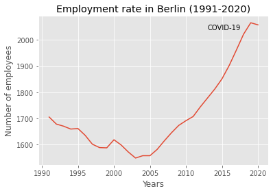

```python
# Change the index values of employment to type integer for plotting
df_total_lineplot.index = df_total_lineplot.index.map(float)

# Plot a line plot by appending .plot() to the employment dataframe
df_total_lineplot.plot(kind='line')

plt.title('Employment rate in Berlin (1991-2020)')
plt.ylabel('Number of employees')
plt.xlabel('Years')

# plt.txt() method: to do annotations in the plot
plt.text(2013, 2040, 'COVID-19')

# Show the updates made to the figure
plt.show()
```

#### Compare the number of employees in different economic sectors

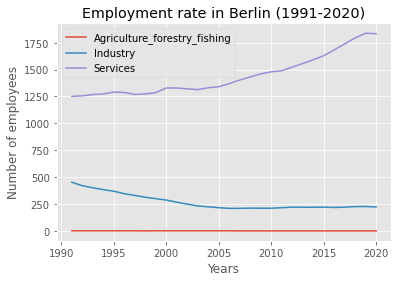

```python
# Get data set for every economic sector and display data frame
df_totals_lineplot= df_original_en.loc[['Agriculture_forestry_fishing', 'Industry', 'Services'], years]

# transpose() method to swap rows and columns
df_totals_lineplot = df_totals_lineplot.transpose()

# Change the index values of the df type integer for plotting
df_totals_lineplot.index = df_totals_lineplot.index.map(int)

# Explicitly specify line plot by passing in kind parameter to plot()
df_totals_lineplot.plot(kind='line')

plt.title('Employment rate in Berlin (1991-2020)')
plt.ylabel('Number of employees')
plt.xlabel('Years')

plt.show()
```

#### Compare the three economic sectors that most contribute to the employment in Berlin

```
                 Public_services_education_health  \
Economic sector
1991                                        525.0
1992                                        536.0
1993                                        541.0
1994                                        553.0
1995                                        572.0
1996                                        581.0
1997                                        578.0
1998                                        581.0
1999                                        587.0
2000                                        607.0
2001                                        610.0
2002                                        617.0
2003                                        608.0
```

[output cut: 83 more lines]

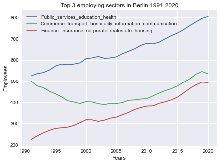

```python
# Step 1: Get the dataset.

# Add a 'Total' column that sums up the total employees by sector
df_detailed = df_detailed.copy()
df_detailed['Total'] = df_detailed.sum(axis=1)
df_detailed.head(2)

# We will sort on this column to get our top 3 countries using pandas sort_values() method.

# inplace = True paramemter saves the changes to the original dataframe
df_detailed.sort_values(by='Total', ascending=False, axis=0, inplace=True)

# get the top 3 entries
df_top3 = df_detailed.head(3)

# transpose the dataframe
df_top3 = df_top3[years].transpose()

print(df_top3)

#Step 2: Plot the dataframe

# To make the plot more readeable, we will change the size using the `figsize` parameter.

df_top3.index = df_top3.index.map(int) # Change the index values to type integer for plotting

df_top3.plot(kind='line', figsize=(7, 5)) # pass a tuple (x, y) size

plt.title('Top 3 employing sectors in Berlin 1991-2020')
plt.ylabel('Employees')
plt.xlabel('Years')

plt.show()
```

### Area plot

**Are plot** or **stacked area plot**: multiple area plots stacked one on top of or below another. Cumulative plots. Area plots are stacked by default. Types: artistic layer, scripting layer, backend layer

```python
# We already added a 'Total' column that sums up the total employees by sector

# df_detailed_with_total_column = df_detailed.copy()
# df_detailed_with_total_column['Total'] = df_detailed.sum(axis=1)
# df_detailed_with_total_column.head(2)
```

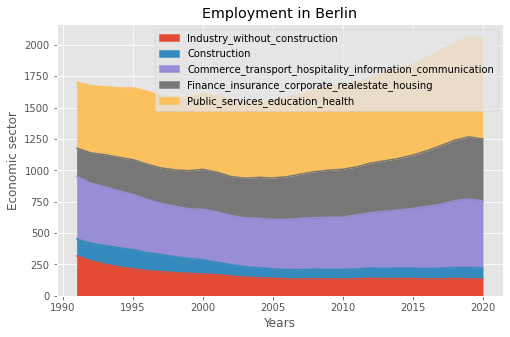

```python
# Area plot, unstacked plot

# Get data set for every economic sector and display data frame
df_detailed_areaplot = df_detailed.loc[['Industry_without_construction',
                                        'Construction',
                                        'Commerce_transport_hospitality_information_communication',
                                        'Finance_insurance_corporate_realestate_housing',
                                        'Public_services_education_health'], years]

# Plot the new data frame

# Transpose the new dataframe
df_detailed_areaplot = df_detailed_areaplot.transpose()

# Change the index values to type integer for plotting
df_detailed_areaplot.index = df_detailed_areaplot.index.map(int)

df_detailed_areaplot.plot(kind='area',
             alpha = 1, # alpha parameter: to modify the default transparency value of 0.5
             stacked=True, # to produce an unstacked plot
             figsize=(8, 5), # pass a tuple (x, y) size
             )

plt.title('Employment in Berlin')
plt.ylabel('Economic sector')
plt.xlabel('Years')

plt.show()
```

#### Compare the three economic sectors that more contribute to the employment in Berlin bwtween 1991 and 2020

```python
df_detailed
```

| Economic sector | 1991 | 1992 | 1993 | 1994 | 1995 | 1996 | 1997 | 1998 | 1999 | 2000 | ... | 2012 | 2013 | 2014 | 2015 | 2016 | 2017 | 2018 | 2019 | 2020 | Total |
| --- | --- | --- | --- | --- | --- | --- | --- | --- | --- | --- | --- | --- | --- | --- | --- | --- | --- | --- | --- | --- | --- |
| Public_services_education_health | 525.0 | 536.0 | 541.0 | 553.0 | 572.0 | 581.0 | 578.0 | 581.0 | 587.0 | 607.0 | ... | 684.0 | 700.0 | 715.0 | 727.0 | 743.0 | 762.0 | 779.0 | 796.0 | 805.0 | 19380.0 |
| Commerce_transport_hospitality_information_communication | 500.0 | 477.0 | 469.0 | 452.0 | 440.0 | 425.0 | 407.0 | 401.0 | 394.0 | 403.0 | ... | 443.0 | 455.0 | 464.0 | 477.0 | 495.0 | 511.0 | 533.0 | 546.0 | 535.0 | 13279.0 |
| Finance_insurance_corporate_realestate_housing | 225.0 | 242.0 | 256.0 | 268.0 | 277.0 | 280.0 | 283.0 | 291.0 | 304.0 | 318.0 | ... | 395.0 | 402.0 | 411.0 | 424.0 | 444.0 | 465.0 | 482.0 | 495.0 | 493.0 | 10552.0 |
| Industry_without_construction | 317.0 | 279.0 | 252.0 | 230.0 | 215.0 | 201.0 | 192.0 | 185.0 | 179.0 | 174.0 | ... | 139.0 | 137.0 | 138.0 | 138.0 | 135.0 | 136.0 | 138.0 | 136.0 | 132.0 | 5024.0 |
| Construction | 135.0 | 141.0 | 148.0 | 154.0 | 153.0 | 144.0 | 137.0 | 127.0 | 120.0 | 113.0 | ... | 81.0 | 82.0 | 82.0 | 82.0 | 82.0 | 84.0 | 87.0 | 90.0 | 90.0 | 3014.0 |

5 rows × 31 columns

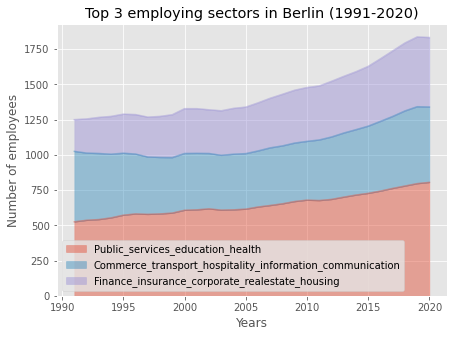

```python
df_top3_areaplot = df_detailed.copy()

df_top3_areaplot.sort_values(['2020'], ascending=False, axis=0, inplace=True)

df_top3_areaplot = df_top3_areaplot.head(3) # get the top 3 entries

df_top3_areaplot = df_top3_areaplot.transpose() # or df_top3_areaplot[years].transpose
df_top3_areaplot.head(3)

df_top3_areaplot.index = df_top3_areaplot.index.map(int) # Change the index vlaues to type integrer for plotting

df_top3_areaplot.plot(kind='area',
                 # stacked=False,
                 alpha = 0.45, # 0-1, default value a= 0.5
                 figsize=(7, 5), # pass a tuple (x, y) size
             )

plt.title('Top 3 employing sectors in Berlin (1991-2020)')
plt.ylabel('Number of employees')
plt.xlabel('Years')

plt.show()
```

### Histograms

Way of representing the frequency distribution (number of observations in an interval) of numeric dataset:

```python
# import matplotlib as mpl
# import matplotlib.pyplot as plt
# %matplotlib inline # to generate the plots within the browser
```

```python
# Examine the data of 'Public Services, Education and Health' split into intervals

df_detailed_t['Public_services_education_health'].tail()
```

```
Economic sector
2016    743.0
2017    762.0
2018    779.0
2019    796.0
2020    805.0
Name: Public_services_education_health, dtype: float64
```

```python
# np.histogram returns 2 values

count, bin_edges = np.histogram(df_detailed_t['Public_services_education_health'])

print(count) # frequency count, distribution, y-axis, number of data points assigned to ech bin
print(bin_edges) # bin ranges, default = 10 bins, x-axis
```

```
[3 3 5 5 2 4 2 2 1 3]
[525. 553. 581. 609. 637. 665. 693. 721. 749. 777. 805.]
```

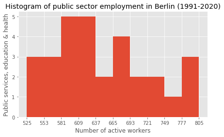

```python
# Graph distribution by passing kind=hist to plot()

df_publicsector_hist = df_detailed_t.copy()

df_publicsector_hist = df_publicsector_hist.astype(int)

df_publicsector_hist['Public_services_education_health'].plot(kind='hist', figsize=(7, 4), xticks=bin_edges)
# xticks keyword that contains the list of the bin sizes, so that the x-axis labels match the bin size
plt.title('Histogram of public sector employment in Berlin (1991-2020)') # add a title to the histogram
plt.ylabel('Public services, education & health') # add y-label
plt.xlabel('Number of active workers') # add x-label

plt.show()
```

#### Plot multiple histograms on the same plot

```python
# df_original_transposed.drop("Total", axis = 0, inplace = True)
```

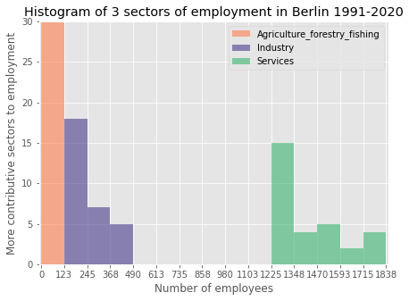

```python
# Create a data frame with the 3 sectors of interest for the histogram

df_top3_hist = df_totals.loc[['Agriculture_forestry_fishing', 'Industry', 'Services'], years]
df_top3_hist = df_top3_hist.transpose() # transpose dataframe
df_top3_hist.head(3)

# df_top3_hist = df_top3_hist.astype(int)

count, bin_edges = np.histogram(df_top3_hist, 15) # get the x-tick values

# Adjust the min and max x-axis labels to remove the extra gap on the edges of the plot
xmin = bin_edges[0] - 10   #  first bin value is 0.0, adding buffer of 10 for aesthetic purposes
xmax = bin_edges[-1] + 10  #  last bin value is 1838.0, adding buffer of 10 for aesthetic purposes

# Generate stacked histogram

df_top3_hist.plot(kind= "hist",
             figsize=(7,5),
             bins=15, # Increase the bin size to 15 by passing in bins parameter
             alpha=0.6, # Set transparency to 60% by passing in alpha parameter
             xticks=bin_edges, # Get the x-tick values
             color=['coral', 'darkslateblue', 'mediumseagreen'], # change the colors of the plots by passing in color parameter
             stacked=True,
             xlim=(xmin, xmax),
             )

plt.title('Histogram of 3 sectors of employment in Berlin 1991-2020') # add a title to the histogram
plt.ylabel('More contributive sectors to employment') # add y-label
plt.xlabel('Number of employees') # add x-label

plt.show()
```

```python
# Full listing of colours

import matplotlib
for name, hex in matplotlib.colors.cnames.items():
    print(name, hex)
```

[output not shown]

## Bar charts

**Bar plot**: way of representing data where the length of the bars represents the magnitude/size of the feature/variable. Usually represent numerical or categorical variables grouped in intervals.

```python
# Get the data

df_total_barplot = df_totals.loc['Total_of_workers', years]
df_total_barplot.head()
```

```
Economic sector
1991    1705.0
1992    1678.0
1993    1670.0
1994    1659.0
1995    1661.0
Name: Total_of_workers, dtype: float64
```

#### Vertical bar graphs

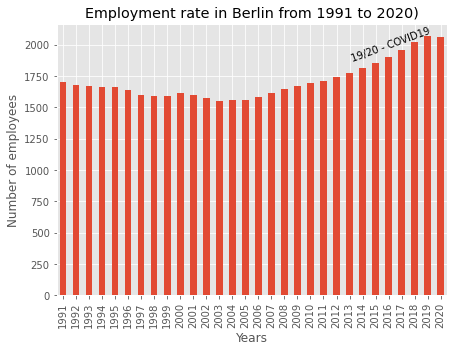

```python
# Plot data

df_total_barplot.plot(kind="bar", figsize=(7, 5), rot=90)

# Annotate text

plt.annotate('19/20 - COVID19', # text to display
             xy=(22, 1850),      # start the text at at point (year 2008 , pop 30)
             rotation=20,       # based on trial and error to match the arrow
             va='bottom',      # text vertically 'bottom' aligned
             ha='left',        # text horizontally 'left' aligned
            )

plt.title("Employment rate in Berlin from 1991 to 2020)")
plt.ylabel("Number of employees") # y-label, y-axis length of bars, corresponds to the magnitude of the variable being measured
plt.xlabel("Years") # x-label, x-axis labelling

plt.show()
```

#### Horizontal bar plot

```python
# We already added a 'Total' column that sums up the total employees by sector

# df_detailed_with_total_column = df_detailed.copy()
# df_detailed_with_total_column['Total'] = df_detailed.sum(axis=1)
# df_detailed_with_total_column.head(2)
```

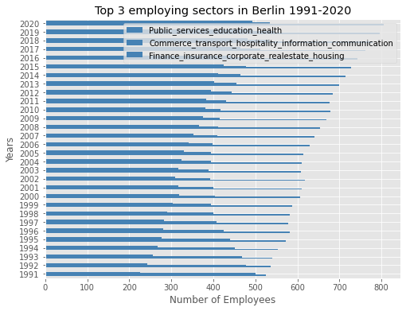

```python
# Step 1: Get the data of the 3 sectors more contributive to employment

# Sort dataframe on 'Total' column (descending)
df_top3_barplot = df_detailed.sort_values(['2020'], ascending=False, axis = 0, inplace=True)

# Get the 3 sectors more contributive to employment
df_top3_barplot = df_detailed.head(3)

# Transpose
df_top3_barplot = df_top3_barplot[years].transpose()
df_top3_barplot.head(3)

# Change the index vlaues to type integrer for plotting
df_top3_barplot.index = df_top3_barplot.index.map(int)

# Generate plot

df_top3_barplot.plot(kind='barh',
                     figsize=(8, 6),
                     color='steelblue')

plt.title('Top 3 employing sectors in Berlin 1991-2020')
plt.xlabel('Number of Employees') # x-axis, length of bars, corresponds to the magnitude of the variable being measured
# y-axis for labelling (more room to label categetorical variables)
plt.ylabel('Years')

plt.show()
```

## Pie charts

**Pie chart**: circular graphic that displays numeric proportions by dividing a circle (or pie) into proportional slices.

```python
df_detailed.sort_values(['2020'], ascending=False, axis = 0)

# Employees per sector for 2020

df_detailed_piechart = {
       'Public_services_education_health': 805.638,
       'Commerce_transport_hospitality_information_communication': 535.699,
       'Finance_insurance_corporate_realestate_housing': 493.093,
       'Industry_without_construction': 132.730,
       'Construction': 90.590,
}
```

```python
# Total of employees for all sectors in 2020

total_employees_2020 = sum(df_detailed_piechart.values())
print(total_employees_2020)
```

```
2057.75
```

```python
# Distribution per sector in percentages

percentage_sector = {}
for sector in df_detailed_piechart:
    percentage_sector[sector] = round((df_detailed_piechart[sector]/2057.75) * 100,2)

# Alternative as dictionary comprehension
percentage_sector = {sector: round((df_detailed_piechart[sector]/2057.75) * 100,2) for sector in df_detailed_piechart}

print(percentage_sector)

# Check if the percentages are 100%
sum(percentage_sector.values())

# Better look of sector names
for sector in percentage_sector.keys():
    print(sector)

# Better look of percentages
for percentage in percentage_sector.values():
    print(percentage)
```

```
{'Public_services_education_health': 39.15, 'Commerce_transport_hospitality_information_communication': 26.03, 'Finance_insurance_corporate_realestate_housing': 23.96, 'Industry_without_construction': 6.45, 'Construction': 4.4}
Public_services_education_health
Commerce_transport_hospitality_information_communication
Finance_insurance_corporate_realestate_housing
Industry_without_construction
Construction
39.15
26.03
23.96
6.45
4.4
```

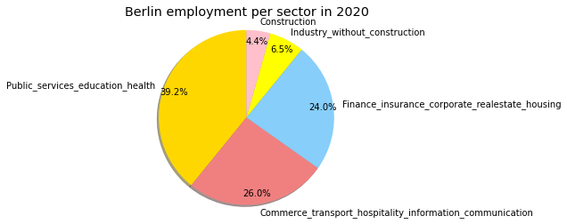

```python
colors_list = ['gold', 'lightcoral', 'lightskyblue', "yellow", "pink"]
explode_list = [0, 0, 0, 0, 0] # ratio for each sector with which to offset each wedge

plt.pie(percentage_sector.values(),
        # figsize=(15,6),
        labels=percentage_sector.keys(), # turn on labels on pie chart
        autopct='%1.1f%%', # add in percentages, fmt%pct fro string format
        shadow=True, # add shadow (3D)
        startangle=90, # start angle 90°
        pctdistance=0.88, # the ratio between the center of each pie slice and the start of the text generated by autopct
        colors=colors_list,
        explode=explode_list,
       )

# Scale the title up by 12% to match pctdistance
plt.title('Berlin employment per sector in 2020', y=1)

plt.axis('equal') # Sets the pie chart to look like a circle.

plt.show()
```

## Box plots

**Box plot**: way of statistically representing the distribution of the data through five main dimensions: minimun, first quartile, second quartile, third quartile, maximum

#### Total of workers in Berlin 1991-2020

```python
# Step 1: get the dataset

# Get a dataframe, place extra square brackets around ''.

df_totals_boxplot = df_totals.loc[['Total_of_workers'], years].transpose()
df_totals_boxplot.head()
```

| Economic sector | Total_of_workers |
| --- | --- |
| 1991 | 1705.0 |
| 1992 | 1678.0 |
| 1993 | 1670.0 |
| 1994 | 1659.0 |
| 1995 | 1661.0 |

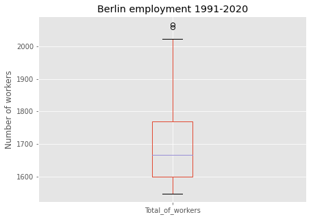

```python
# Step 2: plot data

df_totals_boxplot.plot(kind="box", figsize=(7,5))

plt.title("Berlin employment 1991-2020")
plt.ylabel("Number of workers")
# plt.xlabel("Total of workers")
# plt.xticks([])

plt.show()
```

```python
# Call describe () method to view actual numbers

df_totals_boxplot.describe()
```

|  | Total_of_workers |
| --- | --- |
| count | 30.000000 |
| mean | 1711.266667 |
| std | 153.291234 |
| min | 1548.000000 |
| 25% | 1598.750000 |
| 50% | 1665.500000 |
| 75% | 1769.500000 |
| max | 2066.000000 |

#### Compare sectors of Industry and sector of Services in Berlin 1991-2020

```python
# Compare the distribution of multiple datasets

df_compare_boxplot = df_totals.loc[['Industry', 'Services'], years].transpose()
df_compare_boxplot.head()
```

| Economic sector | Industry | Services |
| --- | --- | --- |
| 1991 | 453.0 | 1251.0 |
| 1992 | 420.0 | 1256.0 |
| 1993 | 401.0 | 1268.0 |
| 1994 | 384.0 | 1274.0 |
| 1995 | 369.0 | 1291.0 |

```python
# Describe()  method to view the percentages associated with both sectors

df_compare_boxplot.describe()
```

|  | Industry | Services |
| --- | --- | --- |
| count | 30.000000 | 30.000000 |
| mean | 268.600000 | 1441.400000 |
| std | 73.477935 | 186.363679 |
| min | 210.000000 | 1251.000000 |
| 25% | 218.500000 | 1288.000000 |
| 50% | 225.000000 | 1355.000000 |
| 75% | 309.750000 | 1548.500000 |
| max | 453.000000 | 1838.000000 |

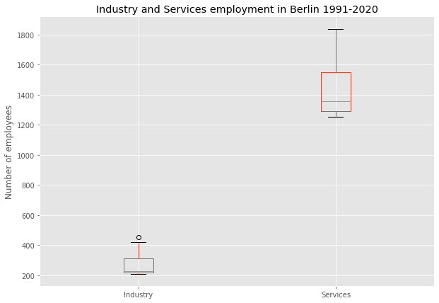

```python
# Step2: plot data

df_compare_boxplot.plot(kind="box", figsize=(10,7))

plt.title("Industry and Services employment in Berlin 1991-2020")
plt.ylabel("Number of employees")

plt.show()
```

### Horizontal box plots

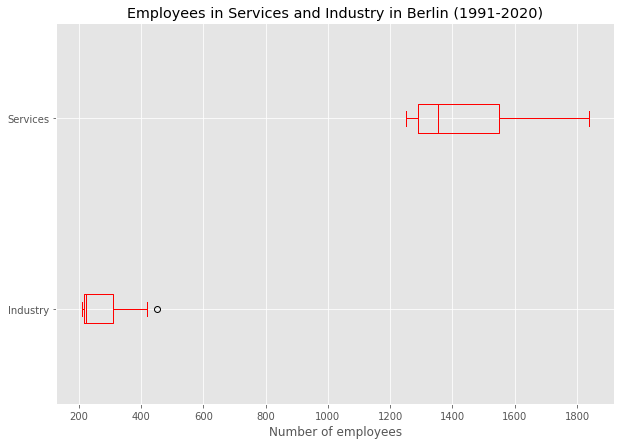

```python
# Plot

df_compare_boxplot.plot(kind="box",
                        figsize=(10,7),
                        color="red",
                        vert=False) # vert paramter

plt.title("Employees in Services and Industry in Berlin (1991-2020)")
plt.xlabel("Number of employees")

plt.show()
```

**Subplots** Figure > subplots > plots

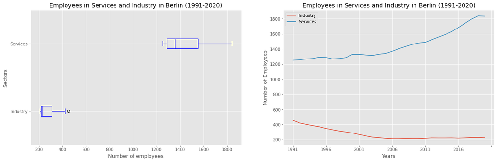

```python
# ax parameter passed into plot() method to specify in which suplot to place each plot

fig = plt.figure() # create figure

ax0 = fig.add_subplot(1, 2, 1) # add subaxes 1 (1 row, 2 columns, 1st plot)
ax1 = fig.add_subplot(122)# () # add subplot 2 (1 row, 2 columns, 2nd plot)

# Subplot 1: Box plot
df_compare_boxplot.plot(kind='box', color='blue', vert=False, figsize=(20, 6), ax=ax0) # add to subplot 1
ax0.set_title('Employees in Services and Industry in Berlin (1991-2020)')
ax0.set_xlabel('Number of employees')
ax0.set_ylabel('Sectors')

# Subplot 2: Line plot
df_compare_boxplot.plot(kind='line', figsize=(20, 6), ax=ax1) # add to subplot 2
ax1.set_title ('Employees in Services and Industry in Berlin (1991-2020)')
ax1.set_ylabel('Number of Employees')
ax1.set_xlabel('Years')

plt.show()
```

Create a box plot to visualize the distribution of the three sectors more contributive to employment in Berlin grouped by the decades 1990s and 2000s

```python
# Step 1: get the dataset

df_top3_boxplot = df_detailed.sort_values(["2020"], ascending=False, axis=0).head(3)
df_top3_boxplot
```

| Economic sector | 1991 | 1992 | 1993 | 1994 | 1995 | 1996 | 1997 | 1998 | 1999 | 2000 | ... | 2011 | 2012 | 2013 | 2014 | 2015 | 2016 | 2017 | 2018 | 2019 | 2020 |
| --- | --- | --- | --- | --- | --- | --- | --- | --- | --- | --- | --- | --- | --- | --- | --- | --- | --- | --- | --- | --- | --- |
| Public_services_education_health | 525.0 | 536.0 | 541.0 | 553.0 | 572.0 | 581.0 | 578.0 | 581.0 | 587.0 | 607.0 | ... | 676.0 | 684.0 | 700.0 | 715.0 | 727.0 | 743.0 | 762.0 | 779.0 | 796.0 | 805.0 |
| Commerce_transport_hospitality_information_communication | 500.0 | 477.0 | 469.0 | 452.0 | 440.0 | 425.0 | 407.0 | 401.0 | 394.0 | 403.0 | ... | 430.0 | 443.0 | 455.0 | 464.0 | 477.0 | 495.0 | 511.0 | 533.0 | 546.0 | 535.0 |
| Finance_insurance_corporate_realestate_housing | 225.0 | 242.0 | 256.0 | 268.0 | 277.0 | 280.0 | 283.0 | 291.0 | 304.0 | 318.0 | ... | 383.0 | 395.0 | 402.0 | 411.0 | 424.0 | 444.0 | 465.0 | 482.0 | 495.0 | 493.0 |

3 rows × 30 columns

```python
# Step 2: create a new dataframe which contains the aggregate for each decade

# 1. Create a list of years in decades 90's and 00's
years_90s = list(map(str, range(1991, 2001)))
years_00s = list(map(str, range(2000, 2021)))

# 2. Slice the original dataframe to create a series for each decade
# and sum across all years for each econmic sector
df_90s = df_top3_boxplot.loc[:, years_90s].sum(axis=1)
df_00s = df_top3_boxplot.loc[:, years_00s].sum(axis=1)

# 3. Merge the two series into a new data frame
new_df = pd.DataFrame({'1990s': df_90s, '2000s':df_00s})
new_df.head() # display dataframe
```

|  | 1990s | 2000s |
| --- | --- | --- |
| Public_services_education_health | 5661.0 | 14326.0 |
| Commerce_transport_hospitality_information_communication | 4368.0 | 9314.0 |
| Finance_insurance_corporate_realestate_housing | 2744.0 | 8126.0 |

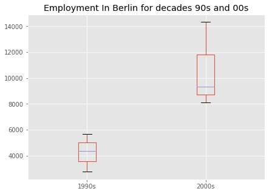

```python
# Step 3: plot the box plots
new_df.plot(kind='box', figsize=(7, 5))
plt.title('Employment In Berlin for decades 90s and 00s')
plt.show()
```

```python
new_df.describe() # statistics associated with the dataframe
```

|  | 1990s | 2000s |
| --- | --- | --- |
| count | 3.000000 | 3.000000 |
| mean | 4257.666667 | 10588.666667 |
| std | 1461.626605 | 3290.680983 |
| min | 2744.000000 | 8126.000000 |
| 25% | 3556.000000 | 8720.000000 |
| 50% | 4368.000000 | 9314.000000 |
| 75% | 5014.500000 | 11820.000000 |
| max | 5661.000000 | 14326.000000 |

**Checking outliers**

- larger than Q3 by at least 1.5 times the interquartile range (IQR), or,
- smaller than Q1 by at least 1.5 times the IQR

```python
new_df = new_df.reset_index()
new_df[new_df['2000s']> 19747.235]
```

|  | index | 1990s | 2000s |
| --- | --- | --- | --- |

### Scatter plots

```python
# Step 1: get the dataset

# We will use the relationship betewen total of workers and years
import pandas as pd
df_totals_scatterplot = pd.DataFrame(df_totals_t[['Total_of_workers']], years)
df_totals_scatterplot.head(1)

# Just in case we wanted to create a df by summing across sectors
# df_totals = pd.DataFrame(df_totals[years].sum(axis=0))
# df_totals = pd.DataFrame(df_totals.sum(axis=1))
```

|  | Total_of_workers |
| --- | --- |
| 1991 | 1705.0 |

```python
# Alternative for creating a scatter plot dataframe
df_totals_scatterplot2 = df_totals.loc[['Total_of_workers'], years]
df_totals_scatterplot2 = df_totals_scatterplot2.T
df_totals_scatterplot2.head()
```

| Economic sector | Total_of_workers |
| --- | --- |
| 1991 | 1705.0 |
| 1992 | 1678.0 |
| 1993 | 1670.0 |
| 1994 | 1659.0 |
| 1995 | 1661.0 |

```python
# Convert the years to type int (useful for regression later on)
df_totals_scatterplot.index = map(int, df_totals_scatterplot.index)
```

```python
# reset the index to put it back as a column in the dataframe
df_totals_scatterplot.reset_index(inplace = True)
df_totals_scatterplot.head(1)
```

|  | index | Total_of_workers |
| --- | --- | --- |
| 0 | 1991 | 1705.0 |

```python
# Rename columns
df_totals_scatterplot.columns = ['Year','Total of workers']

# View the final dataframe
df_totals_scatterplot.head(1)
```

|  | Year | Total of workers |
| --- | --- | --- |
| 0 | 1991 | 1705.0 |

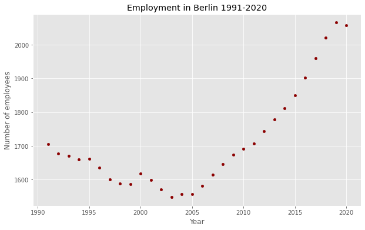

```python
# Step 2: Plot data
import matplotlib.pyplot as plt

df_totals_scatterplot.plot(kind="scatter", x="Year", y="Total of workers", figsize=(10,6), color="darkred")

plt.title("Employment in Berlin 1991-2020")
plt.xlabel("Year")
plt.ylabel("Number of employees")

plt.show()
```

```python
# Step 1: Get the equation of line of best fit

x = df_totals_scatterplot["Year"]. astype(int) # x = df_subtotals_scatterplot.year
y = df_totals_scatterplot["Total of workers"] # or y = df_subtotals_scatterplot.total
employment_modelfit = np.polyfit(x,y,deg=1)# degree of fitting polynomial: 1(linear), 2 (quadratic)...
print(employment_modelfit)
```

```
[ 1.27501669e+01 -2.38591930e+04]
```

[figure not shown]

```
'No. employees = 13 * Year + -23859'
```

```python
# Step 2: Plot the regression line on the scatter plot

df_totals_scatterplot.plot(kind='scatter', x='Year', y='Total of workers', figsize=(7, 5), color='darkblue')

plt.title('Employment in Berlin 1991 - 2020')
plt.xlabel('Years')
plt.ylabel('Number of employees')

# plot line of best fit
plt.plot(x, employment_modelfit[0] * x + employment_modelfit[1], color='red') # recall that x is the Years
plt.annotate('y={0:.0f} x + {1:.0f}'.format(employment_modelfit[0], employment_modelfit[1]), xy=(2000, 15000))

plt.show()

# print out the line of best fit
'No. employees = {0:.0f} * Year + {1:.0f}'.format(employment_modelfit[0], employment_modelfit[1])
```

[output not shown]

And it doesn´t work because our study case it´s not a linear regression

### Bubble plot

**Bubble plot**: variation of the scatter plot that displays three dimensions of data (x, y, z)

```python
# Step 1: get the dataset

# We will use the relationship betewen years and total of workers
# f_totals_bubbleplot = pd.DataFrame(df_totals_t[['Total_of_workers']], years)
# df_totals_bubbleplot.head(1)

# Transpose dataframe
df_totals_bubbleplot = df_totals[years].transpose()
df_totals_bubbleplot.head(3)
```

| Economic sector | Total_of_workers | Agriculture_forestry_fishing | Industry | Services |
| --- | --- | --- | --- | --- |
| 1991 | 1705.0 | 1.0 | 453.0 | 1251.0 |
| 1992 | 1678.0 | 1.0 | 420.0 | 1256.0 |
| 1993 | 1670.0 | 1.0 | 401.0 | 1268.0 |

```python
# Cast the years (the index) to type int
df_totals_bubbleplot.index = map(int, df_totals_bubbleplot.index)
df_totals_bubbleplot.head(1)
```

|  | Total_of_workers | Agriculture_forestry_fishing | Industry | Services |
| --- | --- | --- | --- | --- |
| 1991 | 1705.0 | 1.0 | 453.0 | 1251.0 |

```python
# Label the index. This will automatically be the column name when we reset the index
df_totals_bubbleplot.index.name = 'Year'
```

```python
# Reset index to bring the Year in as a column
df_totals_bubbleplot.reset_index(inplace=True)

# View changes
df_totals_bubbleplot.head(2)
```

|  | Year | Total_of_workers | Agriculture_forestry_fishing | Industry | Services |
| --- | --- | --- | --- | --- | --- |
| 0 | 1991 | 1705.0 | 1.0 | 453.0 | 1251.0 |
| 1 | 1992 | 1678.0 | 1.0 | 420.0 | 1256.0 |

```python
# Step 2. Create the normalized weights (third variable `z`)

# Normalize Industry data
norm_industry = (df_totals_bubbleplot['Industry'] - df_totals_bubbleplot['Industry'].min()) / (df_totals_bubbleplot['Industry'].max() - df_totals_bubbleplot['Industry'].min())

# Normalize Services data
norm_services = (df_totals_bubbleplot['Services'] - df_totals_bubbleplot['Services'].min()) / (df_totals_bubbleplot['Services'].max() - df_totals_bubbleplot['Services'].min())
```

```python
df_totals_bubbleplot = df_totals_bubbleplot.astype(int)
df_totals_bubbleplot.head()
```

|  | Year | Total_of_workers | Agriculture_forestry_fishing | Industry | Services |
| --- | --- | --- | --- | --- | --- |
| 0 | 1991 | 1705 | 1 | 453 | 1251 |
| 1 | 1992 | 1678 | 1 | 420 | 1256 |
| 2 | 1993 | 1670 | 1 | 401 | 1268 |
| 3 | 1994 | 1659 | 1 | 384 | 1274 |
| 4 | 1995 | 1661 | 1 | 369 | 1291 |

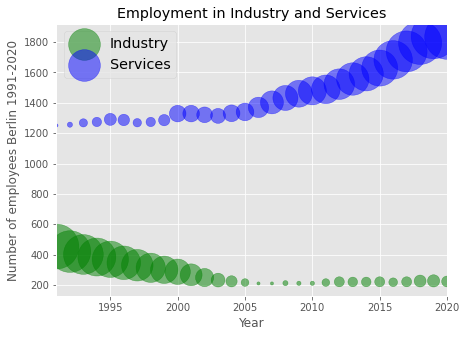

```python
# Step 3. Plot the data

# Industry (Produzierendes Gewerbe)

# ax parameter: passing it to plot two different scatter plots in one plot,
# We include the axes of one plot into the other

# s parameter: to pass in the weights:
# Normalized weights are between 0-1, they won't be visible on the plot
# So we will multiply weights by 2000 to scale it up on the graph
# we will add 10 to compensate for the min value (which has a 0 weight so scale with x2000)

ax0 = df_totals_bubbleplot.plot(kind='scatter',
                    x='Year',
                    y='Industry',
                    figsize=(7,5),
                    alpha=0.5, # transparency
                    color='green',
                    s=norm_industry * 2000 + 10, # pass in weights
                    xlim=(1991, 2020)
                   )

# Services (Dienstleistungsbereiche)
ax1 = df_totals_bubbleplot.plot(kind='scatter',
                    x='Year',
                    y='Services',
                    alpha=0.5,
                    color="blue",
                    s= norm_services * 2000 + 10,
                    ax = ax0
                   )

ax0.set_ylabel('Number of employees Berlin 1991-2020')
ax0.set_title('Employment in Industry and Services')
ax0.legend(['Industry', 'Services'], loc='upper left', fontsize='x-large')
```

Other visualization method

## Regression

### Regression plots

```python
# seaborn: Python visualization library based on matplotlib
# high-level interface for statistical graphics, regression line fit

# install seaborn
# !conda install -c anaconda seaborn --yes

# import libraries
# import numpy as np
# import matplotlib.pyplot as plt
# %matplotlib inline
import seaborn as sns

print('Seaborn installed and imported!')
```

```
Seaborn installed and imported!
```

Create and analyze a dataframe with the total number of employees in Berlin 1991-2020

```python
# Create a dataframe with total of workers and years
df_regplot = pd.DataFrame(df_totals_t[['Total_of_workers']], years)

# Alternative
# df_regplot = df_totals.loc[['Total_of_workers'], years]. transpose()

# If we need to create df_total by summing across different sectors for each year
# df_total_sectors_regplot = pd.DataFrame(df_totals_regplot.sum(axis=1))

# Cast years index to type int (useful for regression later on)
# Or alternatively change year column to int afterwards
# df_regplot.index = map(int, df_regplot.index)

# label the index. This will automatically be the column name when we reset the index
# df_regplot.index.name = 'year'

# Reset the index to put 'year' in back in as a column in the dataframe
df_regplot.reset_index(inplace=True)

# Rename columns
df_regplot.columns = ['Year', 'Employees']

# Change column 'year' from string to int to create scatter plot
df_regplot['Year'] = df_regplot['Year'].astype(int)

# View the final dataframe
df_regplot.head()
```

|  | Year | Employees |
| --- | --- | --- |
| 0 | 1991 | 1705.0 |
| 1 | 1992 | 1678.0 |
| 2 | 1993 | 1670.0 |
| 3 | 1994 | 1659.0 |
| 4 | 1995 | 1661.0 |

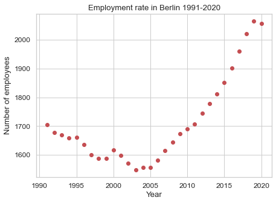

```python
# Plot the dataset

plt.figure(figsize=(7,5))
x_data, y_data = (df_regplot['Year'].values, df_regplot['Employees'].values)
plt.plot(x_data, y_data, 'ro')
plt.title('Employment rate in Berlin 1991-2020')
plt.ylabel('Number of employees')
plt.xlabel('Year')
plt.show()
```

[output not shown]

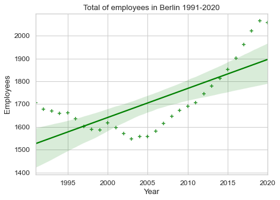

```python
# Regplot funtion to generate a regression plot

import seaborn as sns

plt.figure(figsize=(7,5)) # Blow up the plot

sns.set(font_scale=1.1) # Font size of the tickmark labels, title and x- & y-labels
sns.set_style('whitegrid') # White ackground with gridlines

# Generate plot adding title and axes labels
ax = sns.regplot(x='Year',
                 y='Employees',
                 data=df_regplot,
                 color='green', # customize color of the scatter plot & regression line
                 marker='+', # customize the marker shape
                 scatter_kws={'s':40}, # Size of the markers
                 )
ax.set_title('Total of employees in Berlin 1991-2020') # Add title
ax.set(xlabel='Year', ylabel='Employees') # Add x- and y-labels
```

### Polynomial regression

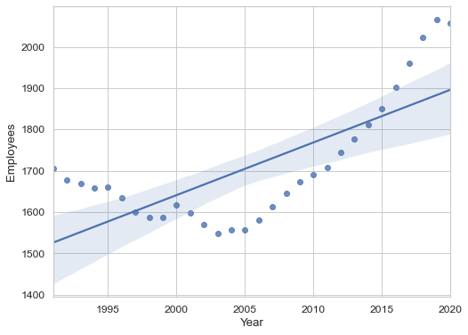

```python
# Alternative: regplot() method

import seaborn as sns

df_polyreg_sns = df_regplot.copy()

plt.figure(figsize=(8, 6))
sns.regplot(x='Year', y='Employees', data=df_polyreg_sns)
# plt.ylim(0,)
# plt.xlim(1,)
plt.show()
```

#### Polynomial regression with SciKit-Learn

```python
from sklearn.linear_model import LinearRegression
from sklearn.preprocessing import PolynomialFeatures
```

```python
# We have some features already selected

df_polyreg_skl = df_regplot.copy()
df_polyreg_skl.head(2)
```

|  | Year | Employees |
| --- | --- | --- |
| 0 | 1991 | 1705.0 |
| 1 | 1992 | 1678.0 |

```python
# Variables: features and target
X = df_polyreg_skl[['Year']] # Independent variable (feature), training data
y = df_polyreg_skl['Employees'] # Dependent variable (target)
```

Train the model

```python
# Create a 4 degree polynomial model (object class PolynomialFeatures)
polyreg_model_skl = PolynomialFeatures(degree=4)

# Step 1: Create a multidemnsional array with method fit_transform() to train the model
X_polyreg_skl = polyreg_model_skl.fit_transform(X)
X_polyreg_skl

# Step 2: Create a LinearRegression model
linreg_model_skl = LinearRegression()

# Step 3: Train the LinearRegression model based on array X_polyreg_scikit
linreg_model_skl.fit(X_polyreg_skl, y)

linreg_model_skl
```

```
LinearRegression()
```

```python
# Employees during the years
Yhat = linreg_model_skl.predict(X_polyreg_skl)
Yhat
```

```
array([1720.73682188, 1695.18135027, 1671.95562129, 1651.10939237,
       1632.69249241, 1616.75482153, 1603.34635127, 1592.51712445,
       1584.31725528, 1578.79692933, 1576.00640344, 1575.99600584,
       1578.81613606, 1584.51726504, 1593.149935  , 1604.76475951,
       1619.41242351, 1637.14368327, 1658.00936638, 1682.06037177,
       1709.34766976, 1739.92230196, 1773.83538132, 1811.13809218,
       1851.88169019, 1896.1175023 , 1943.89692689, 1995.27143363,
       2050.29256348, 2109.01192884])
```

Visualize the results of the estimation for a better overview and compare them to the real information

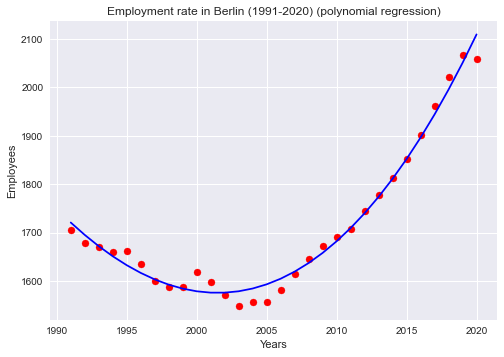

```python
plt.scatter(X, y, color="red")

# X: features (polynomial representation of x), y: target
# Yhat = linreg_model_skl.predict(polyreg_model_skl.fit_transform(X))
plt.plot(X, linreg_model_skl.predict(polyreg_model_skl.fit_transform(X)),color="blue") # or plt.plot(X, Yhat)

plt.title('Employment rate in Berlin (1991-2020) (polynomial regression)')
plt.xlabel('Years')
plt.ylabel('Employees')

plt.style.use('seaborn')

plt.show()
```

#### Polynomial Regression with Pipeline

We need to implement Matplotlib with Pipeline to predict employees for next years

```python
# Import classes and models
from sklearn.pipeline import Pipeline
from sklearn.preprocessing import StandardScaler
from sklearn.preprocessing import PolynomialFeatures
from sklearn.linear_model import LinearRegression
```

```python
# Create an object
Input_workers=[('scale',StandardScaler()),
               ('polynomial',PolynomialFeatures(include_bias=False)),
               ('model',LinearRegression())]
```

```python
# Create a Pipeline-Instanz
pipe_model = Pipeline(Input_workers)
pipe_model
```

```
Pipeline(steps=[('scale', StandardScaler()),
                ('polynomial', PolynomialFeatures(include_bias=False)),
                ('model', LinearRegression())])
```

```python
# Train Pipeline

df_pipe = df_regplot.copy()

df_pipe.info() # Check dataframe structure
```

```
<class 'pandas.core.frame.DataFrame'>
RangeIndex: 30 entries, 0 to 29
Data columns (total 2 columns):
 #   Column     Non-Null Count  Dtype
---  ------     --------------  -----
 0   Year       30 non-null     int32
 1   Employees  30 non-null     float64
dtypes: float64(1), int32(1)
memory usage: 488.0 bytes
```

```python
Z = df_pipe[['Year']] # 2D array (DataFrame object)
y = df_pipe['Employees'] # 1D array (Series object)
pipe.fit(Z, y)
```

```
Pipeline(steps=[('scale', StandardScaler()),
                ('polynomial', PolynomialFeatures(include_bias=False)),
                ('model', LinearRegression())])
```

```python
# Normalize data and predict
ypipe = pipe_model.predict(Z)
ypipe
```

```
array([1729.97258065, 1700.60205784, 1674.24015573, 1650.8868743 ,
       1630.54221357, 1613.20617353, 1598.87875417, 1587.55995551,
       1579.24977753, 1573.94822024, 1571.65528365, 1572.37096774,
       1576.09527253, 1582.828198  , 1592.56974416, 1605.31991101,
       1621.07869855, 1639.84610679, 1661.62213571, 1686.40678532,
       1714.20005562, 1745.00194661, 1778.81245829, 1815.63159066,
       1855.45934372, 1898.29571746, 1944.1407119 , 1992.99432703,
       2044.85656285, 2099.72741935])
```

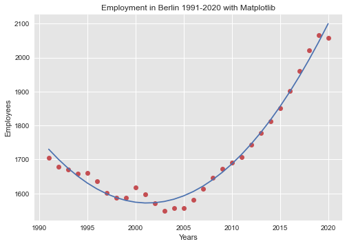

```python
# Visualize outcome

plt.plot(Z, y, 'ro', Z, ypipe, 'b-')
plt.title('Employment in Berlin 1991-2020 with Matplotlib')
ax = plt.gca()
ax.set_facecolor((0.898, 0.898, 0.898))
fig = plt.gcf()
plt.xlabel('Years')
plt.ylabel('Employees')

plt.show()
plt.close()
```

**The prediction for the employment rate in Berlin in 2022 with Pipeline is 2.218.000 millions** as we see below

```python
nextyear = np.array([[2022]])
pipe_model.predict(nextyear)
```

```
array([2218.49499444])
```

**Our model is 98% accurate** as we see below via two different ways

```python
# .score method (): check accuracy of Pipeline object
pipe_model.score(Z, df_pipe['Employees'])
```

```
0.9819845483392955
```

```python
# r2_score also to check Pipeline precision
from sklearn.metrics import r2_score
r_squared = r2_score(y, ypipe)
r_squared
```

```
0.9819845483392955
```

```python
df_pipe.iloc[29]
```

```
Year         2020.0
Employees    2058.0
Name: 29, dtype: float64
```

```python
# MSE value for our Pipeline object
# from sklearn.metrics import mean_squared_error
# mean_squared_error(y, ypipe) # squared=False)
```

#### Polynomial Regression with Numpy

```python
import numpy as np
```

```python
X = df_regplot['Year'] # Training the data: feature
y = df_regplot['Employees'] # Estimation: target

polyreg_model_np = np.polyfit(X, y, 4) # Estimation 4grade
polyreg_model_np
```

```
array([-3.12621450e-03,  2.50870059e+01, -7.54914907e+04,  1.00960748e+08,
       -5.06321462e+10])
```

```python
# numpy.poly1d() function to determine the ecuation

ecuation = np.poly1d(polyreg_model_np)
print(ecuation)
```

```
           4         3             2
-0.003126 x + 25.09 x - 7.549e+04 x + 1.01e+08 x - 5.063e+10
```

```python
# Predict
Yhat = ecuation(X)
Yhat
```

```
array([1695.18315887, 1687.23100281, 1675.95464325, 1662.3805542 ,
       1647.46013641, 1632.0697937 , 1617.01091003, 1603.00978851,
       1590.71779633, 1580.71115112, 1573.49118042, 1569.48404694,
       1569.04102325, 1572.43817902, 1579.87670135, 1591.48270416,
       1607.30725861, 1627.32640839, 1651.44116974, 1679.47753906,
       1711.18650055, 1746.24394989, 1784.2508316 , 1824.73299408,
       1867.14123535, 1910.85149384, 1955.1644516 , 1999.30592346,
       2042.42658997, 2083.60221863])
```

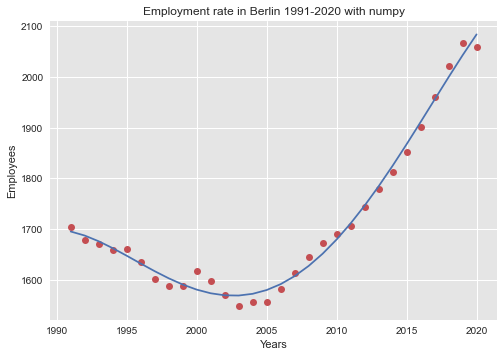

```python
# Visualization with matplotlib

plt.plot(X, y, 'ro', X, Yhat, 'b-')
plt.title('Employment rate in Berlin 1991-2020 with numpy')
ax = plt.gca()
ax.set_facecolor((0.898, 0.898, 0.898))
fig = plt.gcf()
plt.xlabel('Years')
plt.ylabel('Employees')

plt.show()
plt.close()
```

**The prediction for the employment rate in Berlin in 2022 with NumPy is 2.156.000 millions** as we see below

```python
ecuation(2022)
```

```
2156.0458602905273
```

**End of project**